# STAT0006 ICA 3

Group 5

Student numbers: 21117235, 20120251, 21026223, 21026576

### Introduction to the data

In this EDA we want to analyse a dataset containing information about a random subset of a large supermarkets chain’s weekly sales of a certain type of ice cream across their stores. The goal is to understand what factors affect the number of ice creams sold, in order to help the sales team plan for their future sales in ice cream.

The data set we have been asked to analyse has been recorded over the last 5 years, which contains 314 observations on 11 different variables including the number of ice creams of a particular brand sold in a store in a single week; there are also three missing data values. The ten other variables consist of the brand of ice cream for which the sales were counted, the number of other ice cream brands available to buy in the store that week, the distance to the nearest other supermarket store (in miles), whether there was a national bank holiday that week, the wholesale price of milk, reported as the national average that week (in pence per litre), whether there was a promotion running on this brand of ice cream that week, the size of the store, average weekly temperature at the store (Celsius), average weekly wind speed at the store (knots), and the year the sales were recorded.

The average number of ice creams sold in a store in a week is roughly 531 and the standard deviation is roughly 404. The range of ice creams sold in a week is from 0 to 2444. Continuing, we will look at the relationship between sales and the other ten variables in the dataset without taking out the observations that correspond to the missing values.

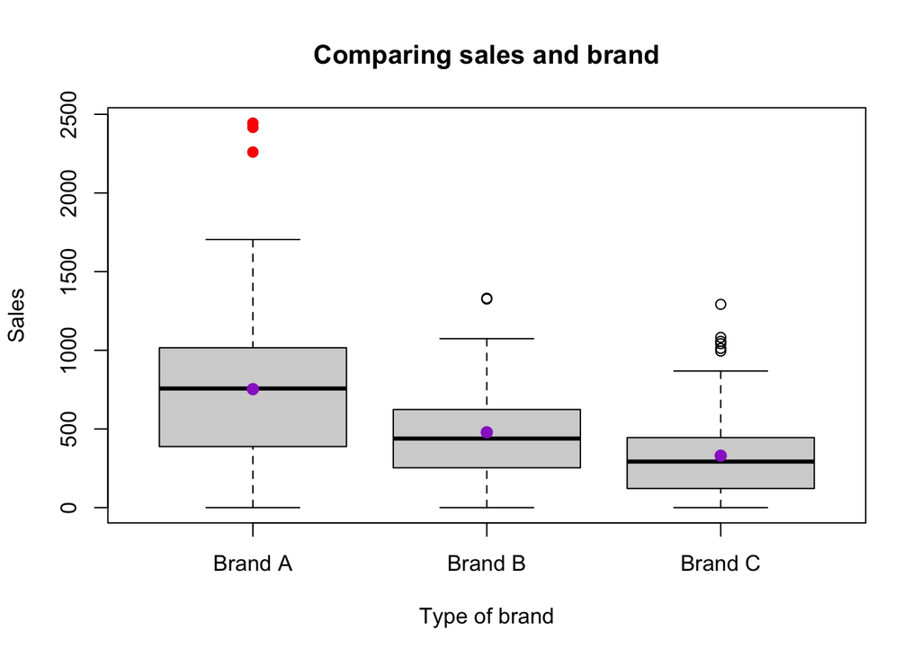

Figure 1: Boxplot comparing number of ice cream sold in a week depdnding on the type of brand. The purple dots show the mean sales in each case. The red dots show possible outliers.

From figure 1, the number of ice cream sold for Brand A is the highest with roughly 753 followed by Brand B with average sales of 479 and Brand C has the fewest average sales of 330. The red points are plausible outliers that are continued to be shown each on the following graphs corresponding to the same three observations which will be further discussed later in the EDA.

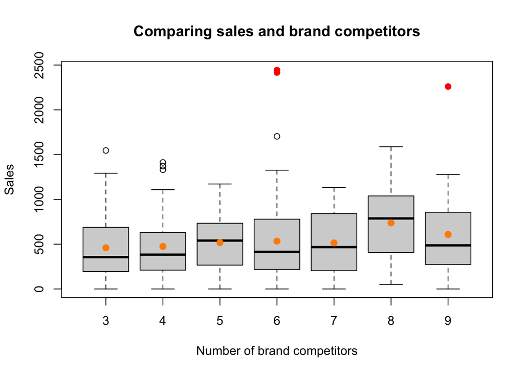

Figure 2: Boxplot comparing number of ice cream sold in a week and the number of other ice cream brands available to buy in the store that week. The orange dots show the mean sales in each case. The red dots show the same possible outliers.

From figure 2, comparing `sales` and `brand_competitors` there is a slight increase in ice cream sales as the number of brand competitors increase. The mean sales of ice cream when there are 3 brand competitors is roughly 459 while when there are 9 brand competitors the average sales is roughly 608.

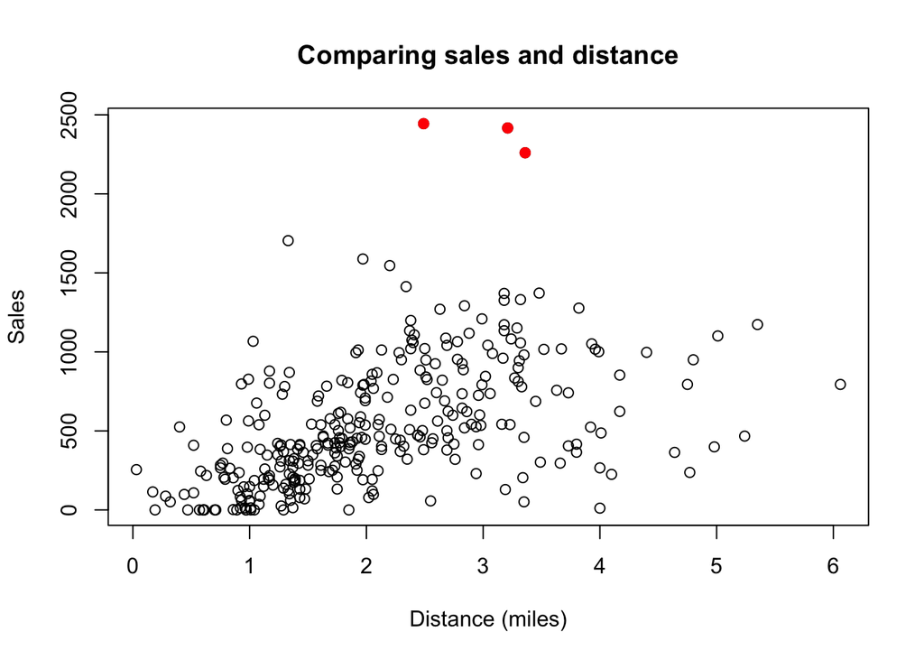

Figure 3: Scatter plot comparing number of ice cream sold in a week and the distance to the nearest other supermarket store (miles). The red dots show the same possible outliers.

Figure 3 shows that there is a moderate positive linear relationship between `sales` and `distance`. From 0 to 3 miles the ice cream sales increase positively linearly. However, after 3 miles the sales stop increasing linearly and there seems to be no distinct relationship between distance and sales.

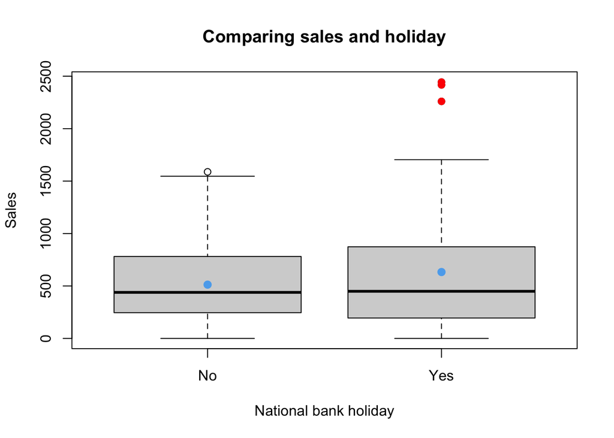

Figure 4: Boxplots to compare the number of ice cream sold in a week and whether there was a national bank holiday during this week. The blue dots show the mean sales in each case while the red dots show the same possible outliers.

From figure 4 the range and mean ice cream sales in a week is larger when there is a national bank holiday.

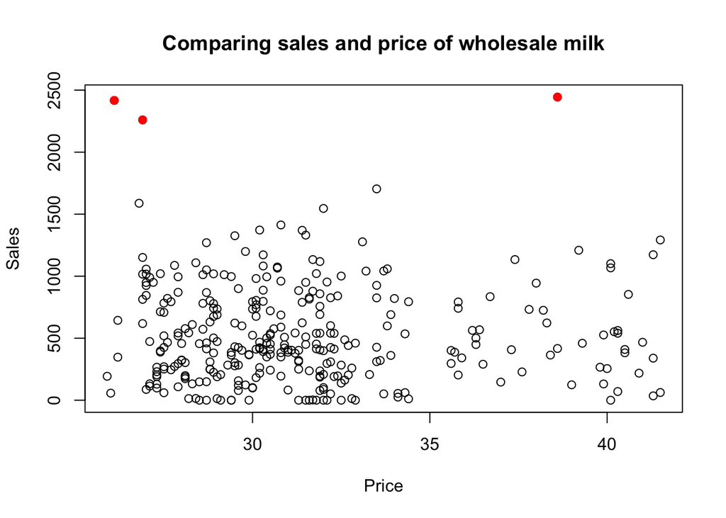

Figure 5: Scatter plot comparing the relationship between number of ice cream sold in a week and the wholsale price of milk (pence per litre). The red outliers show the same possible outliers.

From figure 5, in general price of whole sale milk doesn’t appear to significantly influence ice cream sales in a single week.

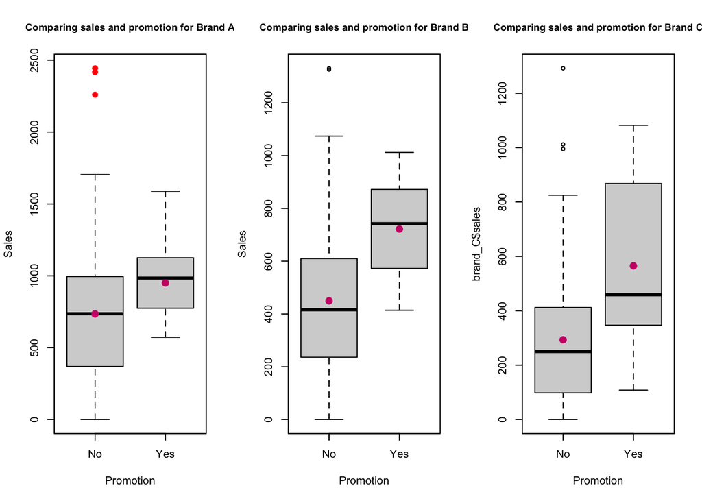

Figure 6: Boxplots comparing the number of ice cream sold in a week and whether there was a promotion running on each brand that week. Leftmost plot for Brand A, middle plot for Brand B and right plot for Brand C. The pink dots show the mean sales in each case while the red dots show the same possible outliers.

Figure 6 shows that for all brands of ice cream, a promotion running on the respective brand appears to increase that brands ice cream sales. In particular, Brand C has highest increase in average ice cream sales when there is a promotion for its brand, followed by Brand B then Brand A.

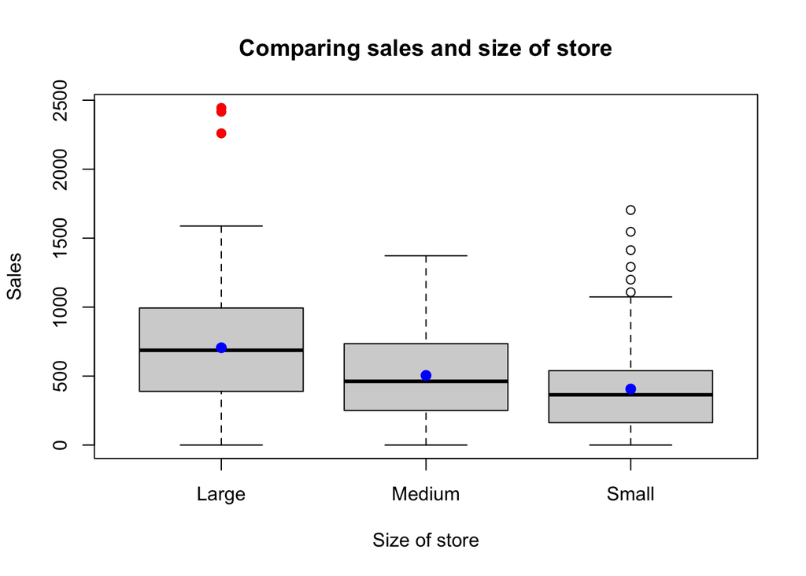

Figure 7: Boxplots comparing the number of ice creams sold in a single week with the size of the store. The blue dots show the mean sales for each case. The red dots show the same possible outliers.

From figure 7 it is apparent that large supermarkets have the highest average sales with roughly mean 705, followed by mediums stores with average sales of roughly 505, and then small stores with average ice cream sales of roughly 406.

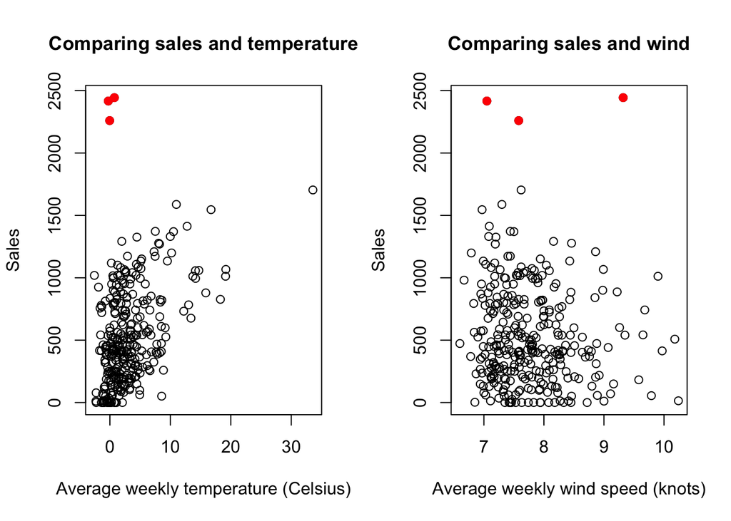

Figure 8: Left plot shows scatterplot comparing relationship between number of ice creams sold in single week and average weekly temperature in store (Celsius). The right scatterplot compares the relationship between number of ice cream sold in a week and the average weekly wind speed at store (knots). The red dots show the same possible outliers.

The left plot in figure 8 shows a positive linear relationship between average weekly temperature at the store and ice cream sales in a week. Thus the higher the temperature in the store, the more ice cream sales there are in the single week. The right plot shows that in general there doesn’t seem to appear to be a relationship between average weekly wind speed at the store and the number of ice creams sold in a week.

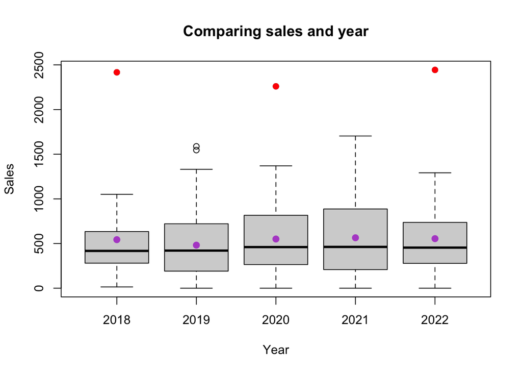

Figure 9: Boxplot comparing ice cream sales and the year sold. The purple dots showcase the mean sales in each case while the red dots show the same possible outliers.

From figure 9 the boxplots show that the range of ice cream sales in a single week was largest in 2021 compared to the other 4 years. However, the median ice cream sales appear to be roughly similar for all five years.

From our plots it is apparent that there may be three outliers corresponding to data rows of 3, 63 and 113 highlighted by the red points for all covariates against `sales`. We can plot some of these graphs again with these three points removed.

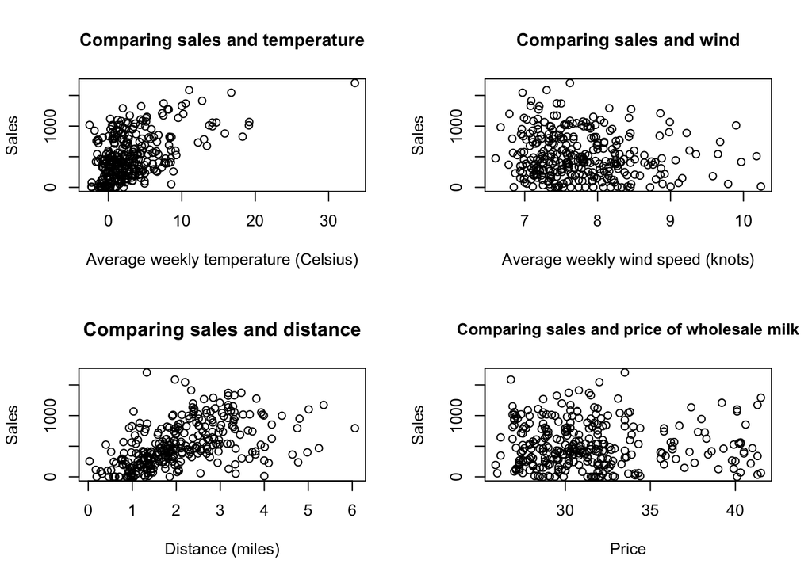

Figure 10: Scatterplots for temperature, wind, distance and milk covariates plotted against sales without found possible outliers.

To conclude 8 of the variables in our dataset appear to be related to the number of ice creams of a particular brand sold in a store in a single week that are worth considering when building our model.

### Model building

We will begin by building Model 1 that includes all covariates and observations in our model using `sales` as our response variable.

**Model 1:**

```
##
## Call:
## lm(formula = sales ~ as.factor(brand) + brand_competitors + distance +
##     as.factor(holiday) + milk + as.factor(promotion) + as.factor(store_type) +
##     temperature + wind + as.factor(year), data = ice_cream)
##
## Residuals:
##     Min      1Q  Median      3Q     Max
## -470.78 -152.42  -22.61  127.74 1559.05
##
## Coefficients:
##                             Estimate Std. Error t value Pr(>|t|)
## (Intercept)                  901.467    292.188   3.085 0.002227 **
## as.factor(brand)BrandB      -239.262     34.873  -6.861 4.03e-11 ***
## as.factor(brand)BrandC      -376.636     36.014 -10.458  < 2e-16 ***
## brand_competitors            -47.588     13.021  -3.655 0.000305 ***
## distance                     171.450     17.304   9.908  < 2e-16 ***
## as.factor(holiday)Y           98.501     40.210   2.450 0.014881 *
## milk                         -14.641      7.975  -1.836 0.067383 .
## as.factor(promotion)Y        209.922     47.941   4.379 1.66e-05 ***
## as.factor(store_type)Medium -165.301     48.782  -3.389 0.000798 ***
## as.factor(store_type)Small  -178.432     59.757  -2.986 0.003064 **
## temperature                   40.083      3.557  11.269  < 2e-16 ***
## wind                          17.797     22.470   0.792 0.428986
## as.factor(year)2019          -17.380     62.891  -0.276 0.782469
## as.factor(year)2020           -3.462     64.529  -0.054 0.957251
## as.factor(year)2021           25.623     69.555   0.368 0.712845
## as.factor(year)2022          113.199    104.738   1.081 0.280675
## ---
## Signif. codes:  0 '***' 0.001 '**' 0.01 '*' 0.05 '.' 0.1 ' ' 1
##
## Residual standard error: 251 on 295 degrees of freedom
##   (3 observations deleted due to missingness)
## Multiple R-squared:  0.6299, Adjusted R-squared:  0.6111
## F-statistic: 33.48 on 15 and 295 DF,  p-value: < 2.2e-16
```

To confirm our speculation about the three outliers we can plot a scatter plot of the standardised residuals against fitted values for the first model. We can observe from Figure 11 that there does seem to appear to be three outliers that correspond to the same points found in the EDA. In addition, due to the three missing observations in our EDA, we will continue to remove these outliers and missing observations when building our next models, starting from Model 2.

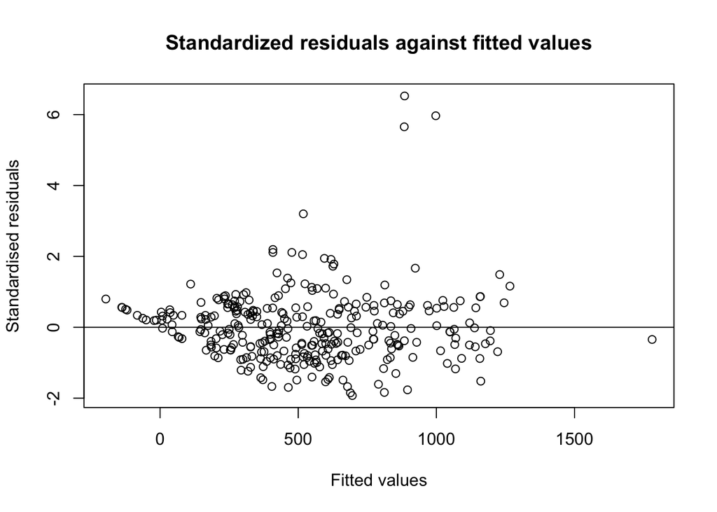

Figure 11: Standardised residuals against fitted values for Model 1

**Model 2:**

```
##
## Call:
## lm(formula = sales ~ as.factor(brand) + brand_competitors + distance +
##     as.factor(holiday) + milk + as.factor(promotion) + as.factor(store_type) +
##     temperature + wind + as.factor(year), data = out_na_ice_cream)
##
## Residuals:
##     Min      1Q  Median      3Q     Max
## -445.90 -122.53  -21.46  117.71  877.33
##
## Coefficients:
##                              Estimate Std. Error t value Pr(>|t|)
## (Intercept)                  536.5999   230.1201   2.332 0.020390 *
## as.factor(brand)BrandB      -191.2191    27.2616  -7.014 1.61e-11 ***
## as.factor(brand)BrandC      -318.9753    28.2327 -11.298  < 2e-16 ***
## brand_competitors            -37.1597    10.1995  -3.643 0.000318 ***
## distance                     179.2267    13.4526  13.323  < 2e-16 ***
## as.factor(holiday)Y          -31.4262    32.5140  -0.967 0.334573
## milk                          -6.0865     6.2218  -0.978 0.328754
## as.factor(promotion)Y        232.7521    37.2187   6.254 1.42e-09 ***
## as.factor(store_type)Medium  -73.5955    38.5179  -1.911 0.057025 .
## as.factor(store_type)Small   -73.2163    47.1652  -1.552 0.121665
## temperature                   44.2260     2.7738  15.944  < 2e-16 ***
## wind                           0.3849    17.6548   0.022 0.982621
## as.factor(year)2019           49.8864    49.7305   1.003 0.316626
## as.factor(year)2020           57.0662    51.1023   1.117 0.265038
## as.factor(year)2021           86.9350    54.7164   1.589 0.113181
## as.factor(year)2022           66.9308    81.7799   0.818 0.413781
## ---
## Signif. codes:  0 '***' 0.001 '**' 0.01 '*' 0.05 '.' 0.1 ' ' 1
##
## Residual standard error: 194.6 on 292 degrees of freedom
## Multiple R-squared:  0.7228, Adjusted R-squared:  0.7086
## F-statistic: 50.77 on 15 and 292 DF,  p-value: < 2.2e-16
```

In Model 2, we have removed three observations, corresponding to the found outliers, where 16 regression coefficients have been estimated which inlcudes one estimated intercept. From our EDA it was noticed that `wind` and `milk` do not have a strong relationship with ice cream sales and thus we will perform two t tests to check whether these covariates should be removed from our regression.

Using Model 2 our hypotheses are:
$$\text{Hypotheses for milk} \begin{cases} H_0:\beta_6 = 0\\ H_A:\beta_6
\ne 0 \end{cases}$$

$$\text{Hypotheses for wind} \begin{cases}H_0:\beta_{11} = 0\\
H_A:\beta_{11} \ne 0 \end{cases}$$
From model 2, our p-value for `milk` is large at value 0.329, we have no evidence to reject the null hypothesis showing that we prefer the model without this covariate. In addition, we see that our p-value for `wind` from our t statistic is large at the value 0.983 showing that we have no evidence to reject the null hypothesis and that we prefer the regression model without this covariate as well.

**Model 3:**

```
##
## Call:
## lm(formula = sales ~ as.factor(brand) + brand_competitors + distance +
##     as.factor(holiday) + as.factor(promotion) + as.factor(store_type) +
##     temperature + as.factor(year), data = out_na_ice_cream)
##
## Residuals:
##     Min      1Q  Median      3Q     Max
## -455.26 -128.89  -19.08  115.17  862.54
##
## Coefficients:
##                             Estimate Std. Error t value Pr(>|t|)
## (Intercept)                  364.103    102.191   3.563 0.000428 ***
## as.factor(brand)BrandB      -193.075     27.123  -7.118 8.39e-12 ***
## as.factor(brand)BrandC      -320.841     27.916 -11.493  < 2e-16 ***
## brand_competitors            -36.782     10.092  -3.645 0.000316 ***
## distance                     178.850     13.421  13.326  < 2e-16 ***
## as.factor(holiday)Y          -32.212     32.377  -0.995 0.320601
## as.factor(promotion)Y        238.560     36.682   6.504 3.36e-10 ***
## as.factor(store_type)Medium  -72.340     38.360  -1.886 0.060301 .
## as.factor(store_type)Small   -72.207     46.941  -1.538 0.125061
## temperature                   44.100      2.762  15.968  < 2e-16 ***
## as.factor(year)2019           43.203     48.886   0.884 0.377559
## as.factor(year)2020           50.706     50.495   1.004 0.316119
## as.factor(year)2021           68.853     51.350   1.341 0.181000
## as.factor(year)2022            6.586     53.260   0.124 0.901673
## ---
## Signif. codes:  0 '***' 0.001 '**' 0.01 '*' 0.05 '.' 0.1 ' ' 1
##
## Residual standard error: 194.3 on 294 degrees of freedom
## Multiple R-squared:  0.7219, Adjusted R-squared:  0.7096
## F-statistic: 58.71 on 13 and 294 DF,  p-value: < 2.2e-16
```

Our hypothesis is:

$$\text{Hypotheses for year} \begin{cases} H_0:\beta_{10} = \beta_{11} =
\beta_{12} = \beta_{13} = 0\\ H_A:\text{At least one of } \beta_{10},
\beta_{11}, \beta_{12} \text{ and } \beta_{13} \text{ is not equal to }
0 \end{cases}$$

```
## Analysis of Variance Table
##
## Model 1: sales ~ as.factor(brand) + brand_competitors + distance + as.factor(holiday) +
##     as.factor(promotion) + as.factor(store_type) + temperature
## Model 2: sales ~ as.factor(brand) + brand_competitors + distance + as.factor(holiday) +
##     as.factor(promotion) + as.factor(store_type) + temperature +
##     as.factor(year)
##   Res.Df      RSS Df Sum of Sq      F Pr(>F)
## 1    298 11237047
## 2    294 11095840  4    141207 0.9354 0.4437
```

From the ANOVA results the p-value from the F-statistic is large suggesting that we have no evidence to reject the null. Concluding that the model without `year` is better.

**Adding interactions:**

Following, we will conduct a F-test to check whether the interaction covariate should be included into the model or not.

```
## Analysis of Variance Table
##
## Model 1: sales ~ as.factor(brand) + brand_competitors + distance + as.factor(holiday) +
##     as.factor(promotion) + as.factor(store_type) + temperature
## Model 2: sales ~ as.factor(brand) + brand_competitors + distance + as.factor(holiday) +
##     as.factor(promotion) + as.factor(store_type) + temperature +
##     distance * as.factor(store_type)
##   Res.Df      RSS Df Sum of Sq      F    Pr(>F)
## 1    298 11237047
## 2    296  7092194  2   4144853 86.495 < 2.2e-16 ***
## ---
## Signif. codes:  0 '***' 0.001 '**' 0.01 '*' 0.05 '.' 0.1 ' ' 1
```

Using ANOVA to compare our two models, one with an interaction between `distance` and `store_type`, the F-test results in a small p-value indicating that we have strong evidence against the null hypothesis that the interaction should be excluded from the regression. Therefore, we prefer the model with the interaction between these covariates, calling it Model 6.

**Model 6:**

```
##
## Call:
## lm(formula = sales ~ as.factor(brand) + brand_competitors + distance +
##     as.factor(holiday) + as.factor(promotion) + as.factor(store_type) +
##     temperature + distance * as.factor(store_type), data = out_na_ice_cream)
##
## Residuals:
##     Min      1Q  Median      3Q     Max
## -295.20 -110.00  -21.20   95.55  558.58
##
## Coefficients:
##                                      Estimate Std. Error t value Pr(>|t|)
## (Intercept)                           726.412     77.122   9.419  < 2e-16 ***
## as.factor(brand)BrandB               -155.215     21.719  -7.147 6.96e-12 ***
## as.factor(brand)BrandC               -280.827     22.380 -12.548  < 2e-16 ***
## brand_competitors                     -34.341      8.028  -4.278 2.55e-05 ***
## distance                               56.780     14.263   3.981 8.65e-05 ***
## as.factor(holiday)Y                   -57.408     25.848  -2.221   0.0271 *
## as.factor(promotion)Y                 232.110     29.221   7.943 4.14e-14 ***
## as.factor(store_type)Medium          -634.120     63.521  -9.983  < 2e-16 ***
## as.factor(store_type)Small           -761.812     66.284 -11.493  < 2e-16 ***
## temperature                            45.629      2.197  20.768  < 2e-16 ***
## distance:as.factor(store_type)Medium  222.943     23.950   9.309  < 2e-16 ***
## distance:as.factor(store_type)Small   355.556     30.612  11.615  < 2e-16 ***
## ---
## Signif. codes:  0 '***' 0.001 '**' 0.01 '*' 0.05 '.' 0.1 ' ' 1
##
## Residual standard error: 154.8 on 296 degrees of freedom
## Multiple R-squared:  0.8223, Adjusted R-squared:  0.8157
## F-statistic: 124.5 on 11 and 296 DF,  p-value: < 2.2e-16
```

We could also analyse the interaction between `distance` and `brand`. This would allow us to observe whether the sales of ice cream depends on how far the nearest supermarket is when considering the specific brand of ice cream for which the sales are being counted. Thus we create Model 7 including an interaction between these two covariates.

Following, we will perform an F-test to examine if we should include this interaction in our regression model.

```
## Analysis of Variance Table
##
## Model 1: sales ~ as.factor(brand) + brand_competitors + distance + as.factor(holiday) +
##     as.factor(promotion) + as.factor(store_type) + temperature +
##     distance * as.factor(store_type)
## Model 2: sales ~ as.factor(brand) + brand_competitors + distance + as.factor(holiday) +
##     as.factor(promotion) + as.factor(store_type) + temperature +
##     distance * as.factor(store_type) + distance * as.factor(brand)
##   Res.Df     RSS Df Sum of Sq      F    Pr(>F)
## 1    296 7092194
## 2    294 5226134  2   1866061 52.488 < 2.2e-16 ***
## ---
## Signif. codes:  0 '***' 0.001 '**' 0.01 '*' 0.05 '.' 0.1 ' ' 1
```

It may be further interesting to look at the interaction between the the brand of ice cream for which sales are being counted and the the number of other ice cream brands available to buy in the store that week. This would allow the observation of how ice cream sales of a particular brand increase or decrease at a different rate with brand competitors depending on which brand sales are being counted. Following model 8 is created with the interaction between these two covariates.

**Model 8:**

```
##
## Call:
## lm(formula = sales ~ as.factor(brand) + brand_competitors + distance +
##     as.factor(holiday) + as.factor(promotion) + as.factor(store_type) +
##     temperature + distance * as.factor(store_type) + distance *
##     as.factor(brand) + brand_competitors * as.factor(brand),
##     data = out_na_ice_cream)
##
## Residuals:
##     Min      1Q  Median      3Q     Max
## -283.54  -72.16  -19.95   58.89  572.88
##
## Coefficients:
##                                          Estimate Std. Error t value Pr(>|t|)
## (Intercept)                               186.299     70.171   2.655  0.00837
## as.factor(brand)BrandB                    378.754     59.459   6.370 7.33e-10
## as.factor(brand)BrandC                    618.215     63.469   9.740  < 2e-16
## brand_competitors                          26.459      8.646   3.060  0.00242
## distance                                  135.209     15.352   8.807  < 2e-16
## as.factor(holiday)Y                       -55.755     19.418  -2.871  0.00439
## as.factor(promotion)Y                     215.750     21.969   9.821  < 2e-16
## as.factor(store_type)Medium              -631.540     47.771 -13.220  < 2e-16
## as.factor(store_type)Small               -801.354     49.926 -16.051  < 2e-16
## temperature                                47.595      1.654  28.783  < 2e-16
## distance:as.factor(store_type)Medium      227.407     18.010  12.627  < 2e-16
## distance:as.factor(store_type)Small       399.023     23.241  17.169  < 2e-16
## as.factor(brand)BrandB:distance           -76.804     17.570  -4.371 1.72e-05
## as.factor(brand)BrandC:distance          -131.599     17.493  -7.523 6.66e-13
## as.factor(brand)BrandB:brand_competitors  -63.181     10.771  -5.866 1.21e-08
## as.factor(brand)BrandC:brand_competitors -105.971     10.901  -9.721  < 2e-16
##
## (Intercept)                              **
## as.factor(brand)BrandB                   ***
## as.factor(brand)BrandC                   ***
## brand_competitors                        **
## distance                                 ***
## as.factor(holiday)Y                      **
## as.factor(promotion)Y                    ***
## as.factor(store_type)Medium              ***
## as.factor(store_type)Small               ***
## temperature                              ***
## distance:as.factor(store_type)Medium     ***
## distance:as.factor(store_type)Small      ***
## as.factor(brand)BrandB:distance          ***
## as.factor(brand)BrandC:distance          ***
## as.factor(brand)BrandB:brand_competitors ***
## as.factor(brand)BrandC:brand_competitors ***
## ---
## Signif. codes:  0 '***' 0.001 '**' 0.01 '*' 0.05 '.' 0.1 ' ' 1
##
## Residual standard error: 116 on 292 degrees of freedom
## Multiple R-squared:  0.9015, Adjusted R-squared:  0.8964
## F-statistic: 178.2 on 15 and 292 DF,  p-value: < 2.2e-16
```

To check whether this interaction helps improve our model we will perform another F-test where the null hypothesis is whether the interaction coefficients equal 0.

```
## Analysis of Variance Table
##
## Model 1: sales ~ as.factor(brand) + brand_competitors + distance + as.factor(holiday) +
##     as.factor(promotion) + as.factor(store_type) + temperature +
##     distance * as.factor(store_type) + distance * as.factor(brand)
## Model 2: sales ~ as.factor(brand) + brand_competitors + distance + as.factor(holiday) +
##     as.factor(promotion) + as.factor(store_type) + temperature +
##     distance * as.factor(store_type) + distance * as.factor(brand) +
##     brand_competitors * as.factor(brand)
##   Res.Df     RSS Df Sum of Sq      F    Pr(>F)
## 1    294 5226134
## 2    292 3930073  2   1296060 48.148 < 2.2e-16 ***
## ---
## Signif. codes:  0 '***' 0.001 '**' 0.01 '*' 0.05 '.' 0.1 ' ' 1
```

From the F-statistic the resulting p-value is small suggesting that we have evidence to reject the null hypothesis. Accordingly, we can include the interaction between `brand` and `brand_competitors` in our linear regression model.

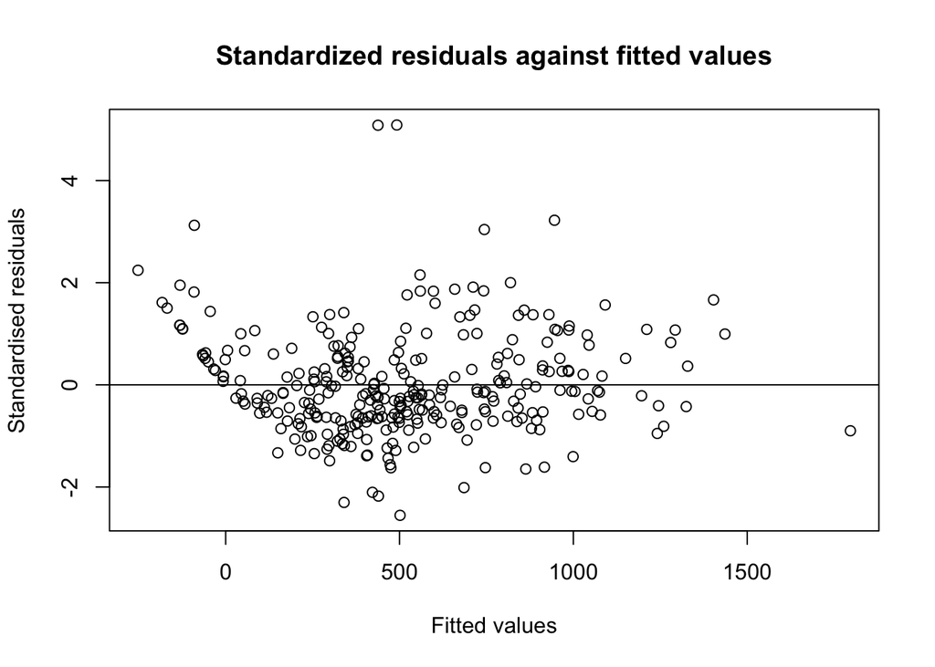

### Model checking for final chosen model

First, we check linearity by plotting `brand_competitors`, `distance` and `temperature` each against the standardised residuals.

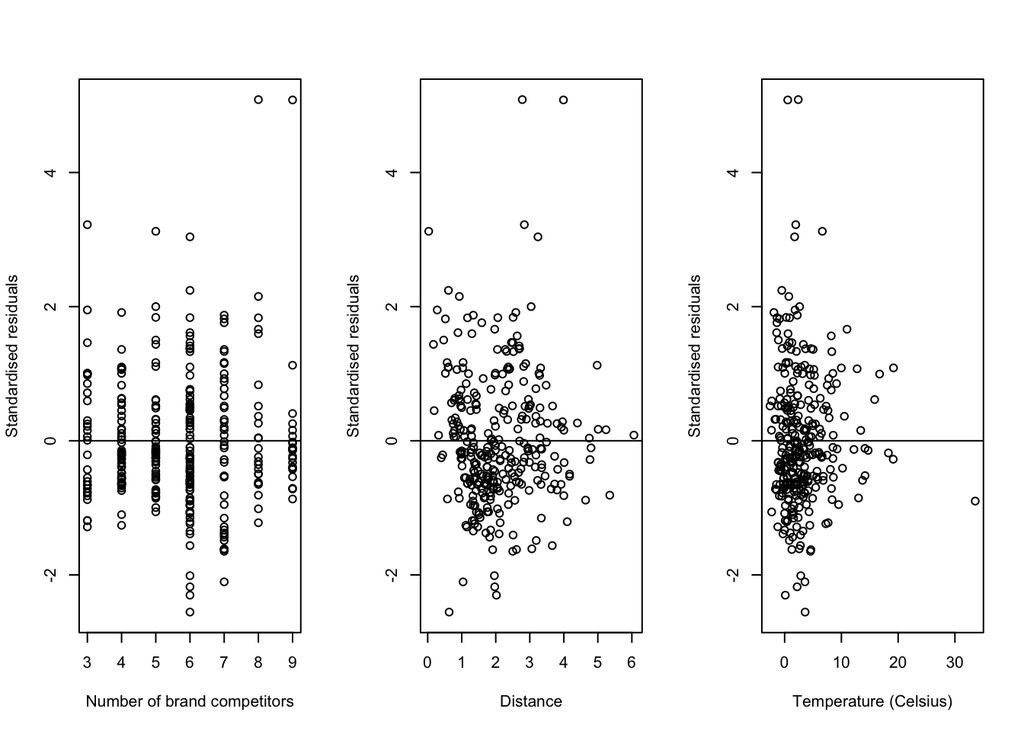

Second, we check normality of error terms using a QQ-plot

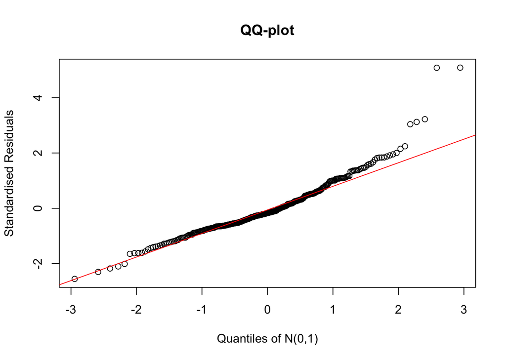

Third, we will check the homoscedasticity of the error term but plotting the standardised residuals against the fitted values.

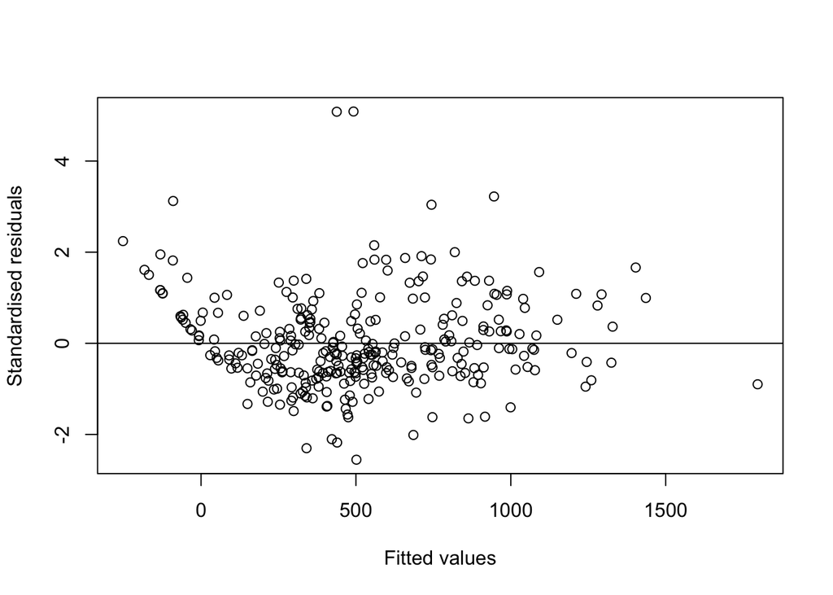